# Wait… you guys are getting paid for your internships?

# Background

Internships are a great opportunity for a person to get relevant experience for their career. They allow an individual to apply the things they’re learning to real-world scenarios and help them know important skills to develop to have a good chance at getting employed after their schooling. Gaining relevant experience is one thing, but all college students would agree that they want not only a paid internship, but an internship that pays well.

This analysis uses a logistic regression model to attempt to see how the probability of the analyst getting a job is predicted by how large the salary is for the internship position.In other words, it seeks to answer the following question:

*Does salary size significantly influence my probability of being hired?*

## Data Collection / Methodology

Data for this analysis was collected by the analyst through the means of artificial intelligence, specifically data was collected through the following steps:

1. The analyst uploaded a copy of their resume to ChatGPT 5.4 as a knowledge source.
2. A custom agent was then given a set of instructions to take in job descriptions and match them with the analyst’s resume to see if the analyst was qualified, being instructed to be as harsh as possible.
3. Job descriptions were then taken from the first page of “Handshake” and fed to the AI agent.
4. The agent was then asked to produce a CSV file containing relevant information such as salary, hiring decision, and factors such as skills fit, experience fit, and education fit.

The data can be seen as follows:

## Data

### Show Data

```r
datatable(gethired)
```

|  | job_id | company | role_title | salary | hiring_decision | skill_match | experience_alignment | education_alignment |
| --- | --- | --- | --- | --- | --- | --- | --- | --- |
| 1 | 1 | RRS Group | AI Research Intern – Real Estate &amp; Tenant Management Systems - Global | 5979.54 | 1 | moderate | moderate | strong |
| 2 | 2 | Skyminyr / HelloSky | AI Data Engineer Intern | 2166.5 | 1 | strong | moderate | strong |
| 3 | 3 | C1 / ConvergeOne | Research and Forecasting AI Intern | 3639.72 | 0 | moderate | weak | moderate |
| 4 | 4 | Alethia Software | AI Engineering Intern | 2600 | 1 | strong | moderate | strong |
| 5 | 5 | OneGard | AI Agent Builder | 4333 | 1 | strong | moderate | moderate |
| 6 | 6 | Unknown | 2026 Intern - People Data Analytics and Visualization | 3986.36 | 0 | moderate | weak | weak |
| 7 | 7 | Johnson &amp; Johnson | AI/ML Intern, Computer Vision | 6456.17 | 0 | weak | weak | moderate |
| 8 | 8 | Jobnova.ai | AI Product Marketing Intern | 3678 | 0 | moderate | weak | moderate |
| 9 | 9 | Drive Hockey Analytics / DivInc | AI ML Engineering Intern | 3336.41 | 1 | moderate | moderate | strong |
| 10 | 10 | Chezie / DivInc | AI Operations Intern | 3336.41 | 1 | strong | strong | strong |

[output cut: 10 more lines]

## Logistic Model

The probability of the analyst getting hired for the job is given by the following logistic regression model.

$$P(Y_i = 1|x_i) =
\frac{e^{\beta_0+\beta_1 x_i}}{1+e^{\beta_0 + \beta_1 x_i}} =
\pi_i$$

In this model, for each job’s hiring decision i:

$Y_i = 1$ means getting hired $Y_i = 0$ means not getting hired $x_i$ denotes the monthly compensation

### Hypothesis

$$H_0 : \beta_1 = 0 :(\text{Salary does
not predict probability of being hired})$$

$$H_a : \beta_1 \neq 0 :(\text{Salary
does predict probability of being hired})$$

$$\alpha = 0.05 :(\text{We'll be
using a significance level of 0.05})$$

## Fitting the model

```r
myGlm <- glm(hiring_decision ~ salary, data = gethired, family = binomial)

summary(myGlm) %>% pander()
```

|  | Estimate | Std. Error | z value | Pr(>\|z\|) |
| --- | --- | --- | --- | --- |
| **(Intercept)** | 1.469 | 1.413 | 1.04 | 0.2985 |
| **salary** | -0.0002845 | 0.000353 | -0.8059 | 0.4203 |

(Dispersion parameter for binomial family taken to be 1 )

| Null deviance: | 26.92 on 19 degrees of freedom |
| --- | --- |
| Residual deviance: | 26.24 on 18 degrees of freedom |

This gives the estimated model for $\pi_i$ as

$$P(Y_i = 1|x_i) \approx
\frac{e^{1.469-0.0002845 x_i}}{1+e^{1.469-0.0002845 x_i}} =
\hat{\pi}_i$$

where $b_0 = 1.469$ and $b_1 = -0.0002845$

The p-Value of salary shows a non significant result (p = 0.4203) which doesn’t give us sufficient evidence to disprove the null hypothesis (
$$H_0 : \beta_1 = 0
:(\text{Salary does not predict probability of being hired})$$
). This means that with the data we have, we cannot say with statistical confidence that salary predicts the probability of the analyst being hired.

## Visualizing the model

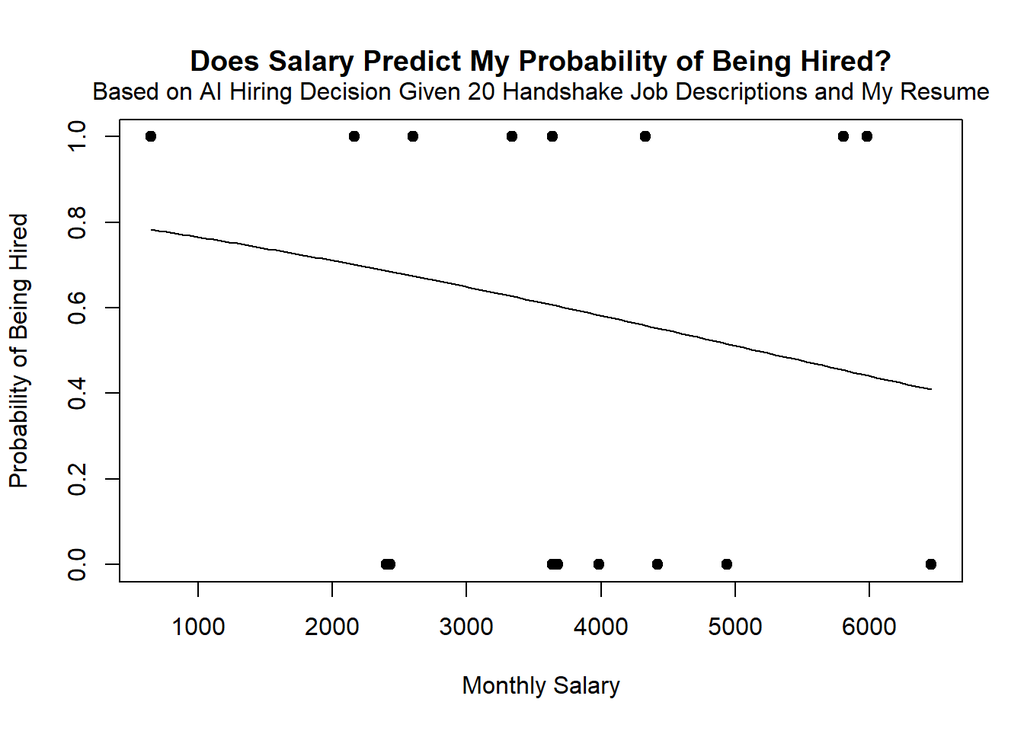

```r
plot(hiring_decision ~ salary, data = gethired,
     pch = 19, xlab = "Monthly Salary", ylab = "Probability of Being Hired", main = "Does Salary Predict My Probability of Being Hired?")
curve(exp(1.4690918 - 0.0002845*x) / (1 + exp(1.4690918 - 0.0002845*x)), add = TRUE)

mtext("Based on AI Hiring Decision Given 20 Handshake Job Descriptions and My Resume", side = 3, line = 0.5)
```

## Diagnosing the Model

```r
table(gethired$salary) %>% pander()
```

Table continues below

| 649.95 | 2166.5 | 2400 | 2433 | 2600 | 3336.41 | 3639.72 | 3678 | 3986.36 |
| --- | --- | --- | --- | --- | --- | --- | --- | --- |
| 1 | 1 | 1 | 1 | 1 | 5 | 2 | 1 | 1 |

| 4333 | 4419.66 | 4939.62 | 5806.22 | 5979.54 | 6456.17 |
| --- | --- | --- | --- | --- | --- |
| 1 | 1 | 1 | 1 | 1 | 1 |

```r
hoslem.test(myGlm$y, myGlm$fitted, g = 10) %>% pander()
```

Hosmer and Lemeshow goodness of fit (GOF) test: `myGlm$y, myGlm$fitted`

| Test statistic | df | P value |
| --- | --- | --- |
| 11.61 | 7 | 0.1142 |

Because the p-value is at 0.1142, we fail to reject the null hypothesis that this model is a good fit. Therefore, based on the Hosmer-Lemeshow Goodness of Fit test, we can say that the logistic regression model is appropriate.

## Conclusion

$\beta_1$ (how salary affects odds of being hired) is -0.0002846 which indicates a slight negative relationship between salary size and probability of being hired. However, because p > $\alpha = 0.05$ @ (p = 0.4203) we cannot disprove the null hypothesis, nor do we have significant evidence to indicate that salary influences the odds of the analyst being hired. This may be because of our small sample size. Further research should use a larger sample size in order to get a clearer answer.

However **if the results were significant** it’s interesting to note that the probability that the analyst can score a job that pays $6000 is 44%. Though this shouldn’t really be referenced, nor should the results of this analysis be used in any way since the p-value is high and because the hiring decision was done by AI.

*Probability of getting a job that pays $6000/mo:*

```r
predict(myGlm, newdata = data.frame(salary = 6000), type = "response") %>% pander(title = "Probability of Landing a Job That Pays $6000 Monthly")
```

| 1 |
| --- |
| 0.4408 |